# Assignment 2.1

Ram Krishna Pudasaini

2023-04-13

**Instruction**

You must do as follows using R Script in R Studio and produce a HTML report (R Markdown) of the same. You must attach both the files i.e. R Script as well as HTML report file for review and grading here.

**Part I: You must use rvest packages for this:**

1. **Get this data in R, make it tidy and do the necessary transformations: https://www.mohfw.gov.in/ (Table: COVID-19 Statewise Status (Click to expand)**)

   ```r
   #load rvest packages
   library(rvest)
   library(tidyr)
   library(rjson)
   library(dplyr)
   #load data from json
   get_data<-jsonlite::fromJSON("https://www.mohfw.gov.in/data/datanew.json")

   #covert to data frame
   covid_data<-as.data.frame(get_data)

   #check the structure
   str(covid_data)
   ```

   ```
   ## 'data.frame':    37 obs. of  14 variables:
   ##  $ sno             : chr  "1" "2" "3" "4" ...
   ##  $ state_name      : chr  "Andaman and Nicobar Islands" "Andhra Pradesh" "Arunachal Pradesh" "Assam" ...
   ##  $ active          : chr  "13" "341" "3" "7" ...
   ##  $ positive        : chr  "10764" "2339785" "66895" "746112" ...
   ##  $ cured           : chr  "10622" "2324711" "66596" "738070" ...
   ##  $ death           : int  129 14733 296 8035 12304 1184 14156 4 26560 4014 ...
   ##  $ new_active      : chr  "13" "359" "3" "7" ...
   ##  $ new_positive    : chr  "10764" "2339833" "66895" "746112" ...
   ##  $ new_cured       : chr  "10622" "2324741" "66596" "738070" ...
   ##  $ new_death       : chr  "129" "14733" "296" "8035" ...
   ##  $ death_reconsille: chr  "" "" "" "" ...
   ##  $ total           : chr  "" "" "" "" ...
   ##  $ state_code      : chr  "35" "28" "12" "18" ...
   ##  $ actualdeath24hrs: chr  "0" "0" "0" "0" ...
   ```

   ```r
   #view data in tabular format
   View(covid_data)
   ```

   **Tidy The Data**

   ```r
   #check for null in anay column
   colSums(is.na(covid_data))
   ```

   ```
   ##              sno       state_name           active         positive
   ##                0                0                0                0
   ##            cured            death       new_active     new_positive
   ##                0                0                0                0
   ##        new_cured        new_death death_reconsille            total
   ##                0                0                0                0
   ##       state_code actualdeath24hrs
   ##                0                0
   ```

   ```r
   # Select State names and total Cases, cured and Deaths
   # select only the relevant columns
   tidy_data <- covid_data%>%
     select(state_name, total, cured, new_death)

   # rename the columns
   names(tidy_data) <- c("State", "Total Cases", "Cured", "Deaths")

   tidy_data
   ```

   ```
   ##                                       State Total Cases    Cured Deaths
   ## 1               Andaman and Nicobar Islands                10622    129
   ## 2                            Andhra Pradesh              2324711  14733
   ## 3                         Arunachal Pradesh                66596    296
   ## 4                                     Assam               738070   8035
   ## 5                                     Bihar           1   839361  12305
   ## 6                                Chandigarh                98484   1184
   ## 7                              Chhattisgarh           1  1164205  14157
   ## 8  Dadra and Nagar Haveli and Daman and Diu                11588      4
   ## 9                                     Delhi           3  1990402  26563
   ## 10                                     Goa*               256823   4014
   ## 11                                  Gujarat           6  1273722  11072
   ## 12                                  Haryana              1049814  10721
   ## 13                         Himachal Pradesh           1   312313   4230
   ## 14                        Jammu and Kashmir               475326   4789
   ```

   [output cut: 23 more lines]

2. **Get this data in R, make it tidy and do the necessary transformation: https://covid19.who.int/table**

   ```r
   #reading data
   covidWhoTable<- jsonlite::fromJSON("https://covid19.who.int/page-data/sq/d/3713876948.json")[[1]][[1]][[1]][[1]] #accessign the list elements data is 4 level deep
   #ccheck by view dataset
   ```

   ```r
   covidWhoTable<- gsub(pattern = "[\\]","",covidWhoTable)
   covidWhoTable<- jsonlite::fromJSON(covidWhoTable)
   colnames(covidWhoTable)   <- gsub(" ","_",colnames(covidWhoTable))
   covidWhoTable <- transmute(covidWhoTable,Country,Confirmed,Cases_Last_7_Days,Deaths,
                           Deaths_Last_7_Days,Doses_Per_100,Persons_fully_vaccinated_with_last_dose_of_primary_series,Boosters_per_100)
   head(covidWhoTable)
   ```

   ```
   ##   Country Confirmed Cases_Last_7_Days  Deaths Deaths_Last_7_Days Doses_Per_100
   ## 1      US 102873924                 0 1118800                  0       201.370
   ## 2      CN  99239252               482  120905                  8       238.966
   ## 3      IN  44768172             34453  531000                 84       159.900
   ## 4      FR  38791479             43637  162176                 96       234.500
   ## 5      DE  38368891              4472  171411                  3       232.300
   ## 6      BR  37319254             60591  700556                317       239.650
   ##   Persons_fully_vaccinated_with_last_dose_of_primary_series Boosters_per_100
   ## 1                                                    68.801           35.089
   ## 2                                                    87.299           56.673
   ## 3                                                    68.993           16.573
   ## 4                                                    78.976           60.913
   ## 5                                                    76.424           62.683
   ## 6                                                    80.117           51.710
   ```

   ```r
   View(covidWhoTable)
   ```

3. **Why the original version of the imbd dataset by Kaggle was taken down? https://www.kaggle.com/datasets/tmdb/tmdb-movie-metadata**

   The original version of the IMDb dataset by Kaggle was taken down due to a legal claim by IMDb. The dataset contained information on movies and TV shows, including ratings and other data that was scraped from IMDb’s website. IMDb claimed that the dataset violated their terms of service, which prohibit scraping and unauthorized use of their data. Kaggle removed the dataset from their platform in response to IMDb’s claim.
4. **Comment on this website’s web scrapping policy: https://help.imdb.com/article/imdb/general-information/can-i-use-imdb-data-in-my-software/G5JTRESSHJBBHTGX#**

   The IMDb web scraping policy states that scraping IMDb data is strictly prohibited, except for personal and non-commercial use. This means that if you are scraping IMDb data for any commercial or public use, you must obtain a license from IMDb first.

**Part II: You must use the tidyverse package for these steps:**

Now go to this website and do as follows: https://www.imdb.com/interfaces/

1. Download the title.ratings.tsv.gz and title.basics.tsv.gz files in your computer from https://datasets.imdbws.com/
2. Copy these files by creating a new folder “imdb” inside the “documents” folder of your computer and unzip them there
3. Set your working directory as “Documents/imdb” with R script/code to import these datasets in R Studio So first thing first now lets load the library necessary for working with the data

   ```r
    #If packages are not installed then install it first
       #install.packages("tidyverse")
       #install.packages("dplyr")

       #load library
       library("tidyverse")
       library("dplyr")

       #setting the working directory
       setwd("C:/Users/ramom/Documents/imdb")
       getwd()
   ```

   ```
   ## [1] "C:/Users/ramom/Documents/imdb"
   ```

4. **Import the “title.ratings.tsv” file using read_tsv function as “df_ratings”**

   ```r
   df_ratings<-read_tsv("title.ratings.tsv")
   head(df_ratings)
   ```

   ```
   ## # A tibble: 6 × 3
   ##   tconst    averageRating numVotes
   ##   <chr>             <dbl>    <dbl>
   ## 1 tt0000001           5.7     1965
   ## 2 tt0000002           5.8      262
   ## 3 tt0000003           6.5     1807
   ## 4 tt0000004           5.6      178
   ## 5 tt0000005           6.2     2604
   ## 6 tt0000006           5.1      179
   ```

5. **Check the structure and get summary of all the variables and interpret them carefully**

   ```r
   str(df_ratings)
   ```

   ```
   ## spc_tbl_ [1,299,877 × 3] (S3: spec_tbl_df/tbl_df/tbl/data.frame)
   ##  $ tconst       : chr [1:1299877] "tt0000001" "tt0000002" "tt0000003" "tt0000004" ...
   ##  $ averageRating: num [1:1299877] 5.7 5.8 6.5 5.6 6.2 5.1 5.4 5.4 5.3 6.9 ...
   ##  $ numVotes     : num [1:1299877] 1965 262 1807 178 2604 ...
   ##  - attr(*, "spec")=
   ##   .. cols(
   ##   ..   tconst = col_character(),
   ##   ..   averageRating = col_double(),
   ##   ..   numVotes = col_double()
   ##   .. )
   ##  - attr(*, "problems")=<externalptr>
   ```

   From the above we can say that the three is [1,299,877] rows and 3 column in the data set: tconst, averageRating and numvotes. The first column is of character type and rest of the two variables are number type.

   Now for the summary

   ```r
   summary(df_ratings)
   ```

   ```
   ##     tconst          averageRating      numVotes
   ##  Length:1299877     Min.   : 1.00   Min.   :      5
   ##  Class :character   1st Qu.: 6.20   1st Qu.:     11
   ##  Mode  :character   Median : 7.10   Median :     26
   ##                     Mean   : 6.95   Mean   :   1039
   ##                     3rd Qu.: 7.90   3rd Qu.:    101
   ##                     Max.   :10.00   Max.   :2725109
   ```

   Before that lets check the NA value in the data set columns

   ```r
   colSums(is.na(df_ratings))
   ```

   ```
   ##        tconst averageRating      numVotes
   ##             0             0             0
   ```

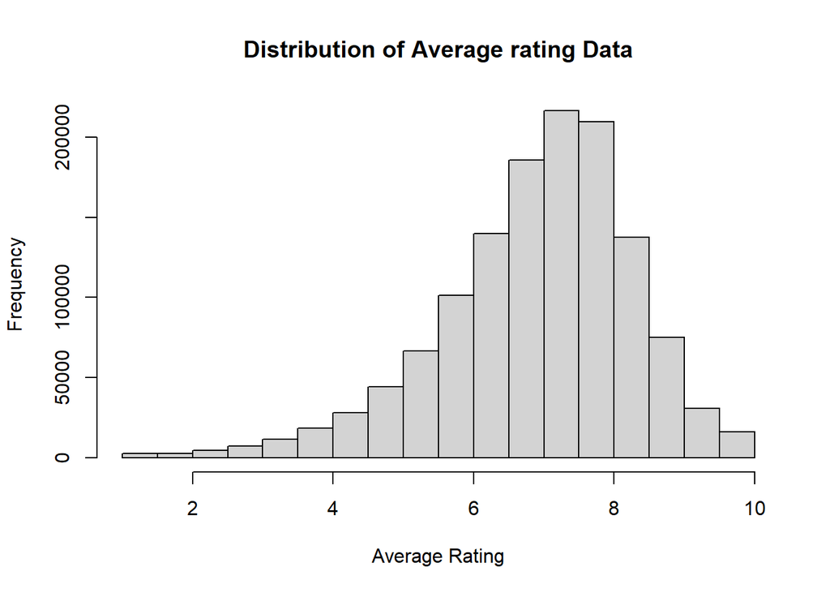

   ```r
   hist(df_ratings$averageRating, main = "Distribution of Average rating Data",xlab ="Average Rating")
   ```

   From the histogram we can say that the data is left skewed data. So for the Skewed data we can take the median. So the average ratings for the data can be 7.1 as the median is 7.1

   Also checking the outliers in the data using boxplot

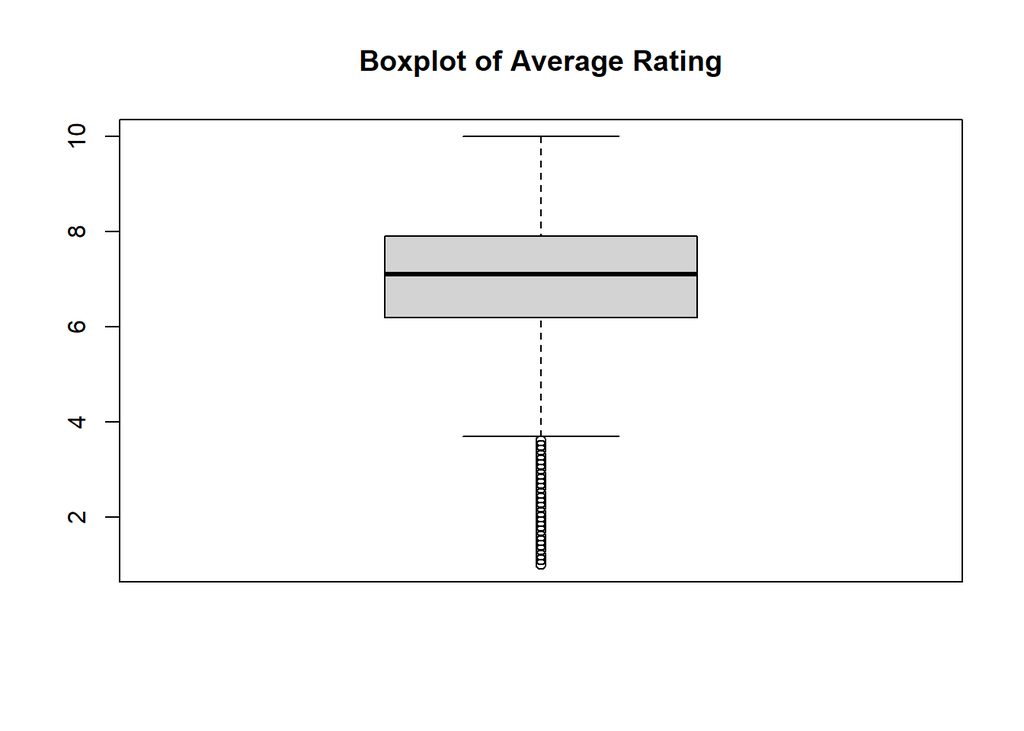

   ```r
   boxplot(df_ratings$averageRating, main="Boxplot of Average Rating")
   ```

   From the boxplot diagram we can see outliers below average.

   Again getting the histogram and boxplot for the variable numvotes

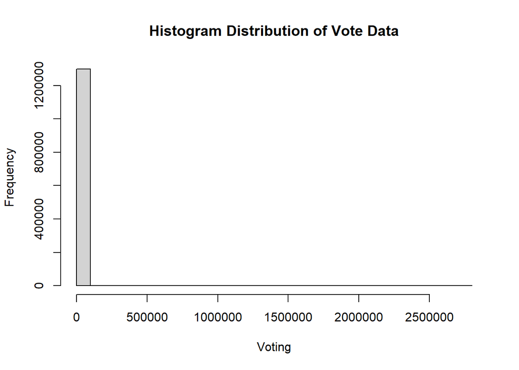

   ```r
   hist(df_ratings$numVotes, main = "Histogram Distribution of Vote Data",xlab ="Voting")
   ```

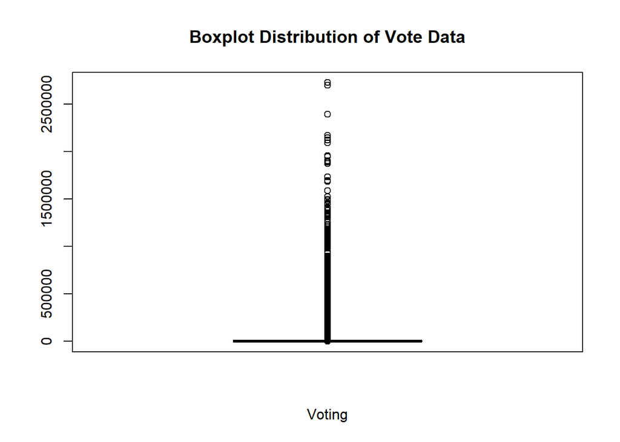

   ```r
   boxplot(df_ratings$numVotes, main = "Boxplot Distribution of Vote Data",xlab ="Voting")
   ```

   From the above distribution data we can figure out that the number of vote is very unusual. Some movie has got huge vote and some has very less vote. Also there are lots of outliers in the data as well. So the summary that we provide for the number of votes will not be handy for proper interpretations. It looks like we need to ignore votes less than 100 and do the summary calculations to find the average vote for the movies.
6. **Is this data set “tidy”? Why?**

   First check whether there is null or NA for each column

   ```r
   colSums(is.na(df_ratings))
   ```

   ```
   ##        tconst averageRating      numVotes
   ##             0             0             0
   ```

   Since there is no any records with null value. we can say it is tidy. Again we need to figure out the Tidy principle to say that the data is Tidy. According to the Tidy principle:

   ->Each variable must have its own column.

   ->Each observation must have its own row.

   ->Each value must have its own cell.

   The Data set follow the above rule so that we can say that the data set : df_ratings is **Tidy**
7. **Get scatterplot of “averageRating” and “numVotes” and interpret it carefully**

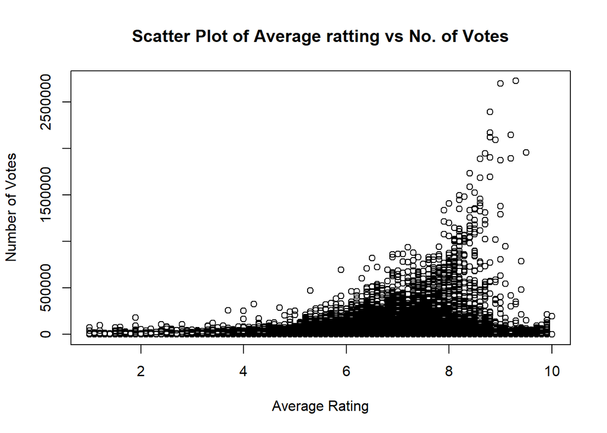

   ```r
   plot(df_ratings$averageRating, df_ratings$numVotes,xlab='Average Rating', ylab='Number of Votes', main='Scatter Plot of Average ratting vs No. of Votes')
   ```

   Get the co relation between two variables average rating and number of votes

   ```r
   cor(df_ratings$averageRating,df_ratings$numVotes, method = "spearman")
   ```

   ```
   ## [1] -0.07420004
   ```

   Here as the plot is non linear then so we use the spearman correlation to find the relationship between two variable. Here the correlation between them is - 0.0742 which is the negative co relations between them. i.e from the data we can say that they are not closely associated .
8. **Import the “title.basics.tsv” file using read_tsv function as “df_ basics”**

   ```r
   df_basics<-read_tsv("title.basics.tsv")
   head(df_basics)
   ```

   ```
   ## # A tibble: 6 × 9
   ##   tconst    titleType primaryTi…¹ origi…² isAdult start…³ endYear runti…⁴ genres
   ##   <chr>     <chr>     <chr>       <chr>     <dbl> <chr>   <chr>   <chr>   <chr>
   ## 1 tt0000001 short     Carmencita  Carmen…       0 1894    "\\N"   1       Docum…
   ## 2 tt0000002 short     Le clown e… Le clo…       0 1892    "\\N"   5       Anima…
   ## 3 tt0000003 short     Pauvre Pie… Pauvre…       0 1892    "\\N"   4       Anima…
   ## 4 tt0000004 short     Un bon bock Un bon…       0 1892    "\\N"   12      Anima…
   ## 5 tt0000005 short     Blacksmith… Blacks…       0 1893    "\\N"   1       Comed…
   ## 6 tt0000006 short     Chinese Op… Chines…       0 1894    "\\N"   1       Short
   ## # … with abbreviated variable names ¹primaryTitle, ²originalTitle, ³startYear,
   ## #   ⁴runtimeMinutes
   ```

9. **Check the structure and get summary of all the variables and interpret them carefully**

````
```r
str(df_basics)
```

```
## spc_tbl_ [9,764,099 × 9] (S3: spec_tbl_df/tbl_df/tbl/data.frame)
##  $ tconst        : chr [1:9764099] "tt0000001" "tt0000002" "tt0000003" "tt0000004" ...
##  $ titleType     : chr [1:9764099] "short" "short" "short" "short" ...
##  $ primaryTitle  : chr [1:9764099] "Carmencita" "Le clown et ses chiens" "Pauvre Pierrot" "Un bon bock" ...
##  $ originalTitle : chr [1:9764099] "Carmencita" "Le clown et ses chiens" "Pauvre Pierrot" "Un bon bock" ...
##  $ isAdult       : num [1:9764099] 0 0 0 0 0 0 0 0 0 0 ...
##  $ startYear     : chr [1:9764099] "1894" "1892" "1892" "1892" ...
##  $ endYear       : chr [1:9764099] "\\N" "\\N" "\\N" "\\N" ...
##  $ runtimeMinutes: chr [1:9764099] "1" "5" "4" "12" ...
##  $ genres        : chr [1:9764099] "Documentary,Short" "Animation,Short" "Animation,Comedy,Romance" "Animation,Short" ...
##  - attr(*, "spec")=
##   .. cols(
##   ..   tconst = col_character(),
##   ..   titleType = col_character(),
##   ..   primaryTitle = col_character(),
##   ..   originalTitle = col_character(),
##   ..   isAdult = col_double(),
##   ..   startYear = col_character(),
##   ..   endYear = col_character(),
##   ..   runtimeMinutes = col_character(),
##   ..   genres = col_character()
##   .. )
##  - attr(*, "problems")=<externalptr>
```

**Analysis**

From the above command we came to find out that the data set consist [9,764,099] records and 9 columns :tconst, titleType,primaryTitle, orginalTitle, isAdult, startYear, endYear, runtimeMinutes,a nd genres. Here the columns have different data type but we need to change some of the data type for best analysis .

After looking into the structure of the data set we can with the conclusion that some column need to be droped (primaryTitle, endYear) as the primary title and original title has the save value for all row and end years doesnot contribute for the further analysis as most of the value is null so we will drop two column. Again we will change the datatype of titleType, startyear, runtimeMinutes to Factor, Integer and Integer from character data type.

We need to make the genres columns atomic as well but we will do it later but first of all lets drop some column and change the data types of the data set.


```r
df_basics<-df_basics%>%select(-c("primaryTitle","endYear"))
#now checking the structure of the data set
str(df_basics)
```

```
## tibble [9,764,099 × 7] (S3: tbl_df/tbl/data.frame)
##  $ tconst        : chr [1:9764099] "tt0000001" "tt0000002" "tt0000003" "tt0000004" ...
##  $ titleType     : chr [1:9764099] "short" "short" "short" "short" ...
##  $ originalTitle : chr [1:9764099] "Carmencita" "Le clown et ses chiens" "Pauvre Pierrot" "Un bon bock" ...
##  $ isAdult       : num [1:9764099] 0 0 0 0 0 0 0 0 0 0 ...
##  $ startYear     : chr [1:9764099] "1894" "1892" "1892" "1892" ...
##  $ runtimeMinutes: chr [1:9764099] "1" "5" "4" "12" ...
##  $ genres        : chr [1:9764099] "Documentary,Short" "Animation,Short" "Animation,Comedy,Romance" "Animation,Short" ...
```

```r
#changing the necessary data type
df_basics$titleType<-as.factor(df_basics$titleType)
df_basics$startYear<-as.integer(df_basics$startYear)
```

```
## Warning: NAs introduced by coercion
```

```r
df_basics$runtimeMinutes<-as.integer(df_basics$runtimeMinutes)
```

```
## Warning: NAs introduced by coercion
```

```r
str(df_basics)
```

```
## tibble [9,764,099 × 7] (S3: tbl_df/tbl/data.frame)
##  $ tconst        : chr [1:9764099] "tt0000001" "tt0000002" "tt0000003" "tt0000004" ...
##  $ titleType     : Factor w/ 11 levels "movie","short",..: 2 2 2 2 2 2 2 2 1 2 ...
##  $ originalTitle : chr [1:9764099] "Carmencita" "Le clown et ses chiens" "Pauvre Pierrot" "Un bon bock" ...
##  $ isAdult       : num [1:9764099] 0 0 0 0 0 0 0 0 0 0 ...
##  $ startYear     : int [1:9764099] 1894 1892 1892 1892 1893 1894 1894 1894 1894 1895 ...
##  $ runtimeMinutes: int [1:9764099] 1 5 4 12 1 1 1 1 45 1 ...
##  $ genres        : chr [1:9764099] "Documentary,Short" "Animation,Short" "Animation,Comedy,Romance" "Animation,Short" ...
```

```r
#get the summary of the datasets
summary(df_basics)
```

```
##     tconst              titleType       originalTitle         isAdult
##  Length:9764099     tvEpisode:7410248   Length:9764099     Min.   :   0.0000
##  Class :character   short    : 923621   Class :character   1st Qu.:   0.0000
##  Mode  :character   movie    : 641670   Mode  :character   Median :   0.0000
##                     video    : 272958                      Mean   :   0.0345
##                     tvSeries : 241391                      3rd Qu.:   0.0000
##                     tvMovie  : 141024                      Max.   :2023.0000
##                     (Other)  : 133187                      NA's   :1
##    startYear       runtimeMinutes       genres
##  Min.   :1874      Min.   :    0     Length:9764099
##  1st Qu.:2001      1st Qu.:   18     Class :character
##  Median :2012      Median :   30     Mode  :character
##  Mean   :2005      Mean   :   44
##  3rd Qu.:2018      3rd Qu.:   60
##  Max.   :2030      Max.   :59460
##  NA's   :1320505   NA's   :6889361
```
````

10. **Is this dataset “tidy”? Why?**

By analyzing the data set we can see that there are lots of null values also it doesn’t follow the tidy principle so we can say that the data set is not tidy yet. we need to tidy them by doing some pre processing.

now checking the null value of the data set

```r
colSums(is.na(df_basics))
```

```
##         tconst      titleType  originalTitle        isAdult      startYear
##              0              0              3              1        1320505
## runtimeMinutes         genres
##        6889361             17
```

[output not shown]

11. **Join “df_basics” variables in “df_ratings” using “left_join” function (name of the joined data must be df_ratings)**

    ```r
    df_ratings<-df_basics%>%left_join(df_ratings, by="tconst")
    head(df_ratings)
    ```

    ```
    ## # A tibble: 6 × 9
    ##   tconst    titleType originalT…¹ isAdult start…² runti…³ genres avera…⁴ numVo…⁵
    ##   <chr>     <fct>     <chr>         <dbl>   <int>   <int> <chr>    <dbl>   <dbl>
    ## 1 tt0000001 short     Carmencita        0    1894       1 Docum…     5.7    1965
    ## 2 tt0000002 short     Le clown e…       0    1892       5 Anima…     5.8     262
    ## 3 tt0000003 short     Pauvre Pie…       0    1892       4 Anima…     6.5    1807
    ## 4 tt0000004 short     Un bon bock       0    1892      12 Anima…     5.6     178
    ## 5 tt0000005 short     Blacksmith…       0    1893       1 Comed…     6.2    2604
    ## 6 tt0000006 short     Chinese Op…       0    1894       1 Short      5.1     179
    ## # … with abbreviated variable names ¹originalTitle, ²startYear,
    ## #   ³runtimeMinutes, ⁴averageRating, ⁵numVotes
    ```

    ```r
    str(df_ratings)
    ```

    ```
    ## tibble [9,764,099 × 9] (S3: tbl_df/tbl/data.frame)
    ##  $ tconst        : chr [1:9764099] "tt0000001" "tt0000002" "tt0000003" "tt0000004" ...
    ##  $ titleType     : Factor w/ 11 levels "movie","short",..: 2 2 2 2 2 2 2 2 1 2 ...
    ##  $ originalTitle : chr [1:9764099] "Carmencita" "Le clown et ses chiens" "Pauvre Pierrot" "Un bon bock" ...
    ##  $ isAdult       : num [1:9764099] 0 0 0 0 0 0 0 0 0 0 ...
    ##  $ startYear     : int [1:9764099] 1894 1892 1892 1892 1893 1894 1894 1894 1894 1895 ...
    ##  $ runtimeMinutes: int [1:9764099] 1 5 4 12 1 1 1 1 45 1 ...
    ##  $ genres        : chr [1:9764099] "Documentary,Short" "Animation,Short" "Animation,Comedy,Romance" "Animation,Short" ...
    ##  $ averageRating : num [1:9764099] 5.7 5.8 6.5 5.6 6.2 5.1 5.4 5.4 5.3 6.9 ...
    ##  $ numVotes      : num [1:9764099] 1965 262 1807 178 2604 ...
    ```

    Now Getting the only one value for the genres

    ```r
    #Data-Preprocessing: removing \n
    df_ratings$genres<-gsub("\\N","",df_ratings$genres)

    #Data-Preprocessing: removing excess spaces
    df_ratings$genres<-gsub(" ","",df_ratings$genres)

    #taking only the first genre of each movie
    df_ratings$genres<-gsub(",.*","",df_ratings$genres)
    ```

    Getting the structure now

    ```r
    str(df_ratings)
    ```

    ```
    ## tibble [9,764,099 × 9] (S3: tbl_df/tbl/data.frame)
    ##  $ tconst        : chr [1:9764099] "tt0000001" "tt0000002" "tt0000003" "tt0000004" ...
    ##  $ titleType     : Factor w/ 11 levels "movie","short",..: 2 2 2 2 2 2 2 2 1 2 ...
    ##  $ originalTitle : chr [1:9764099] "Carmencita" "Le clown et ses chiens" "Pauvre Pierrot" "Un bon bock" ...
    ##  $ isAdult       : num [1:9764099] 0 0 0 0 0 0 0 0 0 0 ...
    ##  $ startYear     : int [1:9764099] 1894 1892 1892 1892 1893 1894 1894 1894 1894 1895 ...
    ##  $ runtimeMinutes: int [1:9764099] 1 5 4 12 1 1 1 1 45 1 ...
    ##  $ genres        : chr [1:9764099] "Documentary" "Animation" "Animation" "Animation" ...
    ##  $ averageRating : num [1:9764099] 5.7 5.8 6.5 5.6 6.2 5.1 5.4 5.4 5.3 6.9 ...
    ##  $ numVotes      : num [1:9764099] 1965 262 1807 178 2604 ...
    ```

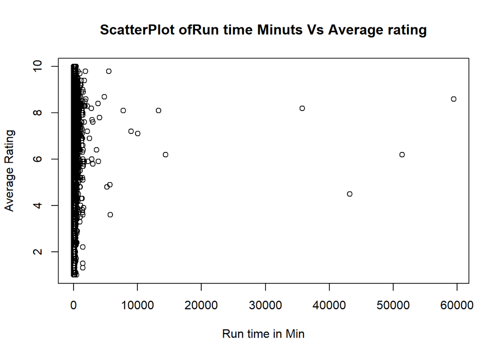

    ```r
    plot(df_ratings$runtimeMinutes,df_ratings$averageRating,main = "ScatterPlot ofRun time Minuts Vs Average rating", xlab = "Run time in Min", ylab = "Average Rating")
    ```

    Getting the Plot
12. **Interpretation**

    Changing the X limit to scale the x axis

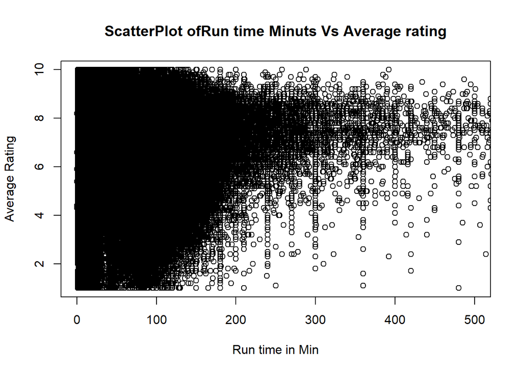

    ```r
    plot(df_ratings$runtimeMinutes,df_ratings$averageRating,main = "ScatterPlot ofRun time Minuts Vs Average rating", xlim= c(0,500),xlab = "Run time in Min", ylab = "Average Rating")
    ```

13. **Get frequency table of “genres” variable using “plyr” package, if required and interpret it carefully**

    ```r
    library(plyr)
    df_ratings["genres"][df_ratings["genres"]=="\\N"]<-NA
    ```

    ```r
    df_ratings$genres<-as.factor(df_ratings$genres)
    ffreqTable<-df_ratings%>%filter(!is.na(genres))
    FT<-count(ffreqTable,"genres")
    FT
    ```

    ```
    ##         genres    freq
    ## 1           \\  440303
    ## 2       Action  388474
    ## 3        Adult  300047
    ## 4    Adventure  237354
    ## 5    Animation  317512
    ## 6    Biography   98985
    ## 7       Comedy 1673269
    ## 8        Crime  283852
    ## 9  Documentary  802387
    ## 10       Drama 2064980
    ## 11         ews  730200
    ## 12      Family  291746
    ## 13     Fantasy   44619
    ## 14    Film-oir      33
    ## 15   Game-Show  217163
    ## 16     History   30389
    ## 17      Horror   92044
    ## 18       Music  194959
    ## 19     Musical   25432
    ## 20     Mystery   27878
    ## 21  Reality-TV  336568
    ## 22     Romance  117156
    ## 23      Sci-Fi   35776
    ## 24       Short  229001
    ## 25       Sport  130299
    ## 26   Talk-Show  601469
    ## 27    Thriller   35635
    ## 28         War    2817
    ## 29     Western   13735
    ```

    ```r
    by_genres<-df_ratings%>%group_by(genres)
    by_genres
    ```

    ```
    ## # A tibble: 9,764,099 × 9
    ## # Groups:   genres [30]
    ##    tconst    titleType original…¹ isAdult start…² runti…³ genres avera…⁴ numVo…⁵
    ##    <chr>     <fct>     <chr>        <dbl>   <int>   <int> <fct>    <dbl>   <dbl>
    ##  1 tt0000001 short     Carmencita       0    1894       1 Docum…     5.7    1965
    ##  2 tt0000002 short     Le clown …       0    1892       5 Anima…     5.8     262
    ##  3 tt0000003 short     Pauvre Pi…       0    1892       4 Anima…     6.5    1807
    ##  4 tt0000004 short     Un bon bo…       0    1892      12 Anima…     5.6     178
    ##  5 tt0000005 short     Blacksmit…       0    1893       1 Comedy     6.2    2604
    ##  6 tt0000006 short     Chinese O…       0    1894       1 Short      5.1     179
    ##  7 tt0000007 short     Corbett a…       0    1894       1 Short      5.4     816
    ##  8 tt0000008 short     Edison Ki…       0    1894       1 Docum…     5.4    2102
    ##  9 tt0000009 movie     Miss Jerry       0    1894      45 Roman…     5.3     205
    ## 10 tt0000010 short     La sortie…       0    1895       1 Docum…     6.9    7108
    ## # … with 9,764,089 more rows, and abbreviated variable names ¹originalTitle,
    ## #   ²startYear, ³runtimeMinutes, ⁴averageRating, ⁵numVotes
    ```

15. **Get mean of runtimeMinutes variables using summarise function by genres, remove NA in runtimeMinutes if required**

    ```r
    RuntimeMean <- by_genres %>%
      filter(!is.na(runtimeMinutes))%>%group_by(genres) %>%
      summarise(mean = mean(runtimeMinutes,na.rm = TRUE))

    RuntimeMean
    ```

    ```
    ##       mean
    ## 1 43.55186
    ```

16. **Get mean of runtimeMinutes variables using summarise by genres without creating “by_genres” object**

    ```r
    RuntimeMeanWithout <- df_ratings %>%
      filter(!is.na(runtimeMinutes))%>%group_by(genres) %>%
      summarise(mean = mean(runtimeMinutes,na.rm = TRUE))

    RuntimeMeanWithout
    ```

    ```
    ##       mean
    ## 1 43.55186
    ```

17. **What is difference between step 19 and step 20? Which one do you prefer? Why? Interpret the result of your choice.**

    In the first step we create the new object that is grouped by genres then we filter the NA row and get the mean by using the summarize function. For the later we use the existing data frame df_rating and calculate the mean by using the pipe operates directly. I prefer second on as there is no need to create extra object to do the calculation we can directly calculate the mean from the existing data frame df_rating which is the join table of df_ratings and df_basic
18. **#Filter “df_ratings” data with runtimeMinutes less than 150 minutes and save it as “df_ratings_movie150m”**

    ```r
    df_rating_movie150m<-df_ratings%>%filter(runtimeMinutes<150)
    df_rating_movie150m
    ```

    ```
    ## # A tibble: 2,827,120 × 9
    ##    tconst    titleType original…¹ isAdult start…² runti…³ genres avera…⁴ numVo…⁵
    ##    <chr>     <fct>     <chr>        <dbl>   <int>   <int> <fct>    <dbl>   <dbl>
    ##  1 tt0000001 short     Carmencita       0    1894       1 Docum…     5.7    1965
    ##  2 tt0000002 short     Le clown …       0    1892       5 Anima…     5.8     262
    ##  3 tt0000003 short     Pauvre Pi…       0    1892       4 Anima…     6.5    1807
    ##  4 tt0000004 short     Un bon bo…       0    1892      12 Anima…     5.6     178
    ##  5 tt0000005 short     Blacksmit…       0    1893       1 Comedy     6.2    2604
    ##  6 tt0000006 short     Chinese O…       0    1894       1 Short      5.1     179
    ##  7 tt0000007 short     Corbett a…       0    1894       1 Short      5.4     816
    ##  8 tt0000008 short     Edison Ki…       0    1894       1 Docum…     5.4    2102
    ##  9 tt0000009 movie     Miss Jerry       0    1894      45 Roman…     5.3     205
    ## 10 tt0000010 short     La sortie…       0    1895       1 Docum…     6.9    7108
    ## # … with 2,827,110 more rows, and abbreviated variable names ¹originalTitle,
    ## #   ²startYear, ³runtimeMinutes, ⁴averageRating, ⁵numVotes
    ```

19. **#Get scatterplot of runtimeMinutes and averageRating variable for this new data and interpret then carefully**

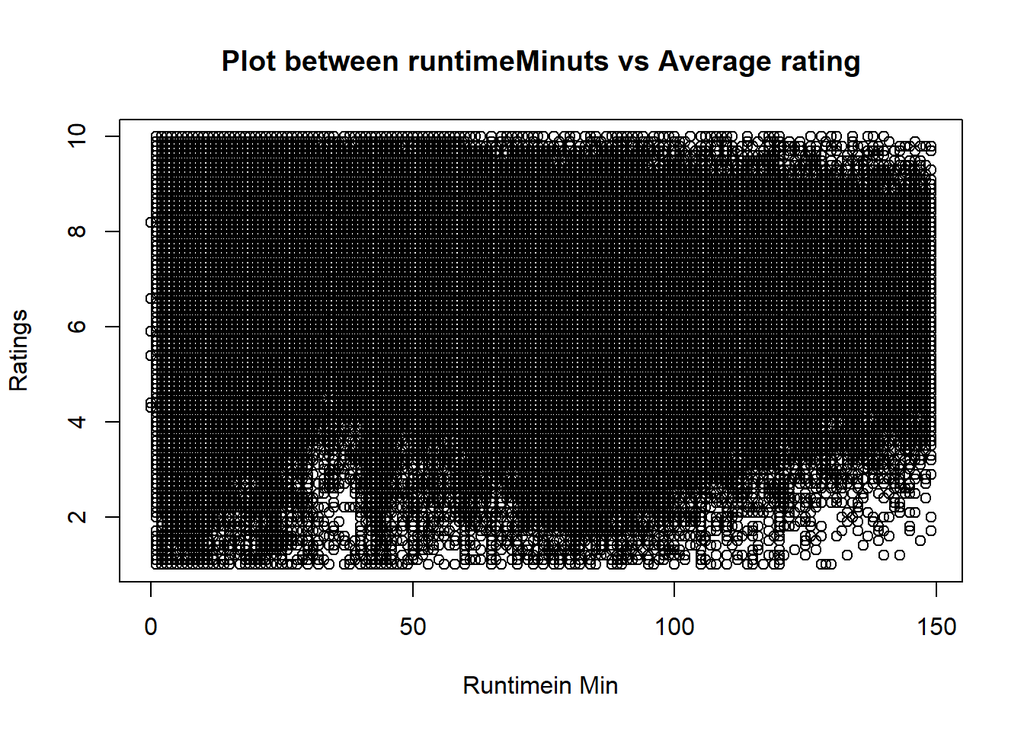

    ```r
    plot(df_rating_movie150m$runtimeMinutes,df_rating_movie150m$averageRating,main = "Plot between runtimeMinuts vs Average rating", xlab = "Runtimein Min", ylab = "Ratings")
    ```

20. **#Arrange the df_rating_movie150m data in descending order by averageRating and save it as “best_worst_movies”**

    ```r
    best_worst_movies<-arrange(df_rating_movie150m,desc(averageRating))
    best_worst_movies
    ```

    ```
    ## # A tibble: 2,827,120 × 9
    ##    tconst    titleType original…¹ isAdult start…² runti…³ genres avera…⁴ numVo…⁵
    ##    <chr>     <fct>     <chr>        <dbl>   <int>   <int> <fct>    <dbl>   <dbl>
    ##  1 tt0127236 video     Renegades…       1    1995      91 "Adul…      10      23
    ##  2 tt0160316 movie     Girls Lov…       1    1996      60 "Adul…      10      14
    ##  3 tt0236477 tvMovie   Die Marqu…       0    1961      80 "Dram…      10      12
    ##  4 tt0237125 short     Cradle So…       0    1981      24 "Shor…      10      20
    ##  5 tt0258117 short     Sally in …       0    1916      40 "Roma…      10      12
    ##  6 tt0270900 tvMovie   Crumbles …       0    1967      88 "Dram…      10      20
    ##  7 tt0270927 tvMovie   Das Ende …       0    1963      43 "Come…      10      11
    ##  8 tt0281732 short     Closed fo…       0    1997       4 "Shor…      10      11
    ##  9 tt0295190 tvMovie   Autobiogr…       0    1964      90 "Dram…      10      12
    ## 10 tt0300220 tvMovie   Mrs. Chen…       0    1957      60 "\\"        10      10
    ## # … with 2,827,110 more rows, and abbreviated variable names ¹originalTitle,
    ## #   ²startYear, ³runtimeMinutes, ⁴averageRating, ⁵numVotes
    ```

21. **#Show the top 6 and last 6 movies based on the arranged dataset above**

    ```r
    #top 6
    head(best_worst_movies)
    ```

    ```
    ## # A tibble: 6 × 9
    ##   tconst    titleType originalT…¹ isAdult start…² runti…³ genres avera…⁴ numVo…⁵
    ##   <chr>     <fct>     <chr>         <dbl>   <int>   <int> <fct>    <dbl>   <dbl>
    ## 1 tt0127236 video     Renegades 2       1    1995      91 Adult       10      23
    ## 2 tt0160316 movie     Girls Lovi…       1    1996      60 Adult       10      14
    ## 3 tt0236477 tvMovie   Die Marqui…       0    1961      80 Drama       10      12
    ## 4 tt0237125 short     Cradle Song       0    1981      24 Short       10      20
    ## 5 tt0258117 short     Sally in O…       0    1916      40 Roman…      10      12
    ## 6 tt0270900 tvMovie   Crumbles l…       0    1967      88 Drama       10      20
    ## # … with abbreviated variable names ¹originalTitle, ²startYear,
    ## #   ³runtimeMinutes, ⁴averageRating, ⁵numVotes
    ```

    ```r
    #last 6
    tail(best_worst_movies)
    ```

    ```
    ## # A tibble: 6 × 9
    ##   tconst    titleType originalT…¹ isAdult start…² runti…³ genres avera…⁴ numVo…⁵
    ##   <chr>     <fct>     <chr>         <dbl>   <int>   <int> <fct>    <dbl>   <dbl>
    ## 1 tt9916680 movie     De la ilus…       0    2007     100 Docum…      NA      NA
    ## 2 tt9916688 tvEpisode Horrid Hen…       0    2012      10 Adven…      NA      NA
    ## 3 tt9916692 tvMovie   Teatroteka…       0    2015      66 Drama       NA      NA
    ## 4 tt9916724 short     Hay Que Se…       0    2015       3 Docum…      NA      NA
    ## 5 tt9916754 movie     Chico Albu…       0    2013      49 Docum…      NA      NA
    ## 6 tt9916856 short     The Wind          0    2015      27 Short       NA      NA
    ## # … with abbreviated variable names ¹originalTitle, ²startYear,
    ## #   ³runtimeMinutes, ⁴averageRating, ⁵numVotes
    ```

22. **#Get the averageRating of adult movies (isAdult variable) using mutate function and interpret it carefully**

    To get the averageRating of adult movies based on the isAdult variable using the mutate() function in R, you can use the following code

    ```r
     #calculate the average rating of adult movies
    avg_rating_adult <- best_worst_movies%>%
      filter(isAdult == 1) %>%
     mutate(avg_rating = mean(averageRating))

    # view the resulting table
    avg_rating_adult
    ```

    ```
    ## # A tibble: 103,479 × 10
    ##    tconst title…¹ origi…² isAdult start…³ runti…⁴ genres avera…⁵ numVo…⁶ avg_r…⁷
    ##    <chr>  <fct>   <chr>     <dbl>   <int>   <int> <fct>    <dbl>   <dbl>   <dbl>
    ##  1 tt012… video   Renega…       1    1995      91 "Adul…      10      23      NA
    ##  2 tt016… movie   Girls …       1    1996      60 "Adul…      10      14      NA
    ##  3 tt030… video   Las pu…       1    1999      65 "Adul…      10      10      NA
    ##  4 tt030… video   Boob C…       1    1998      90 "\\"        10      15      NA
    ##  5 tt030… video   Lana &…       1    1999      60 "Adul…      10       8      NA
    ##  6 tt035… video   Strap-…       1    2000      51 "Adul…      10       7      NA
    ##  7 tt079… video   Daddy …       1    2005     109 "Adul…      10      10      NA
    ##  8 tt084… video   Cop Co…       1    1998      90 "Adul…      10      17      NA
    ##  9 tt095… video   Privat…       1    2006     120 "Adul…      10      20      NA
    ## 10 tt116… video   Lords …       1    2003     108 "Adul…      10       7      NA
    ## # … with 103,469 more rows, and abbreviated variable names ¹titleType,
    ## #   ²originalTitle, ³startYear, ⁴runtimeMinutes, ⁵averageRating, ⁶numVotes,
    ## #   ⁷avg_rating
    ```

    ```r
    #best_worst_movies %>% mutate(adult = ifelse(isAdult == 1, averageRating,"No") )
    #best_worst_movies
    ```

23. **#Divide the “df_ratings_movies150m” into training and testing dataset with 80% and 20% split with slice function**

    ```r
    #get the total row of Df
    totalRow<-nrow(df_rating_movie150m)
    totalRow
    ```

    ```
    ## [1] 2827120
    ```

    ```r
    #Spliting the data into 80% traning data
    traning_data<-df_rating_movie150m%>%slice(1:round(0.8*totalRow))
    traning_data
    ```

    ```
    ## # A tibble: 2,261,696 × 9
    ##    tconst    titleType original…¹ isAdult start…² runti…³ genres avera…⁴ numVo…⁵
    ##    <chr>     <fct>     <chr>        <dbl>   <int>   <int> <fct>    <dbl>   <dbl>
    ##  1 tt0000001 short     Carmencita       0    1894       1 Docum…     5.7    1965
    ##  2 tt0000002 short     Le clown …       0    1892       5 Anima…     5.8     262
    ##  3 tt0000003 short     Pauvre Pi…       0    1892       4 Anima…     6.5    1807
    ##  4 tt0000004 short     Un bon bo…       0    1892      12 Anima…     5.6     178
    ##  5 tt0000005 short     Blacksmit…       0    1893       1 Comedy     6.2    2604
    ##  6 tt0000006 short     Chinese O…       0    1894       1 Short      5.1     179
    ##  7 tt0000007 short     Corbett a…       0    1894       1 Short      5.4     816
    ##  8 tt0000008 short     Edison Ki…       0    1894       1 Docum…     5.4    2102
    ##  9 tt0000009 movie     Miss Jerry       0    1894      45 Roman…     5.3     205
    ## 10 tt0000010 short     La sortie…       0    1895       1 Docum…     6.9    7108
    ## # … with 2,261,686 more rows, and abbreviated variable names ¹originalTitle,
    ## #   ²startYear, ³runtimeMinutes, ⁴averageRating, ⁵numVotes
    ```

    ```r
    dim(traning_data) #getting the dimention of data in row and column
    ```

    ```
    ## [1] 2261696       9
    ```

    ```r
    #Testing data of 20 %
    testing_data<-df_rating_movie150m%>%slice(round(0.8*totalRow)+1:totalRow)
    testing_data
    ```

    ```
    ## # A tibble: 565,424 × 9
    ##    tconst    titleType original…¹ isAdult start…² runti…³ genres avera…⁴ numVo…⁵
    ##    <chr>     <fct>     <chr>        <dbl>   <int>   <int> <fct>    <dbl>   <dbl>
    ##  1 tt5525420 tvShort   Lesbos SOS       0    2015       8 Docum…    NA        NA
    ##  2 tt5525426 short     Punt             0    2007       6 Drama     NA        NA
    ##  3 tt5525442 tvEpisode Petra Pel…       0    2016      69 Talk-…    NA        NA
    ##  4 tt5525446 video     Private S…       1    1998     100 Adult     NA        NA
    ##  5 tt5525452 movie     Towards t…       0    2016     143 Crime     NA        NA
    ##  6 tt5525456 tvSeries  Bandit Pa…       0    2015      60 Reali…     8.9      49
    ##  7 tt5525460 short     Talker           0    2008      24 Drama     NA        NA
    ##  8 tt5525504 movie     Shi kai d…       0    2015     100 Comedy     6.1      72
    ##  9 tt5525506 movie     Ji guang …       0    2014     110 Roman…     3        98
    ## 10 tt5525516 short     Anatomia …       0    2014       6 Short     NA        NA
    ## # … with 565,414 more rows, and abbreviated variable names ¹originalTitle,
    ## #   ²startYear, ³runtimeMinutes, ⁴averageRating, ⁵numVotes
    ```

    ```r
    dim(testing_data)
    ```

    ```
    ## [1] 565424      9
    ```

24. **#Get mean, standard deviation, median and interquartile range of averageRating, numVotes and runtimeMinutes variable of training and testing data and interpret them carefully**

    ```r
    #get the necessary information from the traning data set
    train_Df<-traning_data%>% summarise(mean_averageRating = mean(averageRating,na.rm = TRUE),
                               mean_numVotes = mean(numVotes,na.rm = TRUE),
                               mean_runtimeMinutes = mean(runtimeMinutes,na.rm = TRUE),
                               sd_averageRating = sd(averageRating,na.rm=TRUE),
                               sd_numVotes = sd(numVotes,na.rm=TRUE),
                               sd_runtimeMinutes = sd(runtimeMinutes,na.rm = TRUE),
                               median_averageRating = median(averageRating,na.rm=TRUE),
                               median_numVotes = median(numVotes,na.rm=TRUE),
                               median_runtimeMinutes = median(runtimeMinutes,na.rm = TRUE),
                               IQR_averageRating = IQR(averageRating,na.rm=TRUE),
                               IQR_numVotes = IQR(numVotes,na.rm=TRUE),
                               IQR_runtimeMinutes = IQR(runtimeMinutes,na.rm = TRUE))
    table(train_Df)
    ```

    ```
    ## , , mean_runtimeMinutes = 41.4014916239848, sd_averageRating = 1.32874452812459, sd_numVotes = 19704.1724133903, sd_runtimeMinutes = 31.879537656445, median_averageRating = 7, median_numVotes = 38, median_runtimeMinutes = 30, IQR_averageRating = 1.7, IQR_numVotes = 143, IQR_runtimeMinutes = 42
    ##
    ##                   mean_numVotes
    ## mean_averageRating 1427.20286348416
    ##   6.83969389456939                1
    ```

    ```r
    View(train_Df)  #view the details in tabular form
    ```

    Here we get the mean , sd, median and IQR for different variables like runtimeMinutes, averageRating, numvVotes.

    Now Performing calculation on the test data Set.

    ```r
    test_df<-testing_data%>% summarise(mean_averageRating = mean(averageRating,na.rm = TRUE),
                              mean_numVotes = mean(numVotes,na.rm = TRUE),
                              mean_runtimeMinutes = mean(runtimeMinutes,na.rm = TRUE),
                              sd_averageRating = sd(averageRating,na.rm=TRUE),
                              sd_numVotes = sd(numVotes,na.rm=TRUE),
                              sd_runtimeMinutes = sd(runtimeMinutes,na.rm = TRUE),
                              median_averageRating = median(averageRating,na.rm=TRUE),
                              median_numVotes = median(numVotes,na.rm=TRUE),
                              median_runtimeMinutes = median(runtimeMinutes,na.rm = TRUE),
                              IQR_averageRating = IQR(averageRating,na.rm=TRUE),
                              IQR_numVotes = IQR(numVotes,na.rm=TRUE),
                              IQR_runtimeMinutes = IQR(runtimeMinutes,na.rm = TRUE))
    table(test_df)
    ```

    ```
    ## , , mean_runtimeMinutes = 36.920434930247, sd_averageRating = 1.3844649212685, sd_numVotes = 9436.42152472163, sd_runtimeMinutes = 28.7014108191621, median_averageRating = 7.2, median_numVotes = 27, median_runtimeMinutes = 30, IQR_averageRating = 1.6, IQR_numVotes = 136, IQR_runtimeMinutes = 35
    ##
    ##                   mean_numVotes
    ## mean_averageRating 782.211359494867
    ##   7.00898905894969                1
    ```

    ```r
    View(test_df)
    ```

25. **#Get histogram of averageRating, numVotes and runtimeMinutes variables of training and testing data; compare them and interpret them carefully**

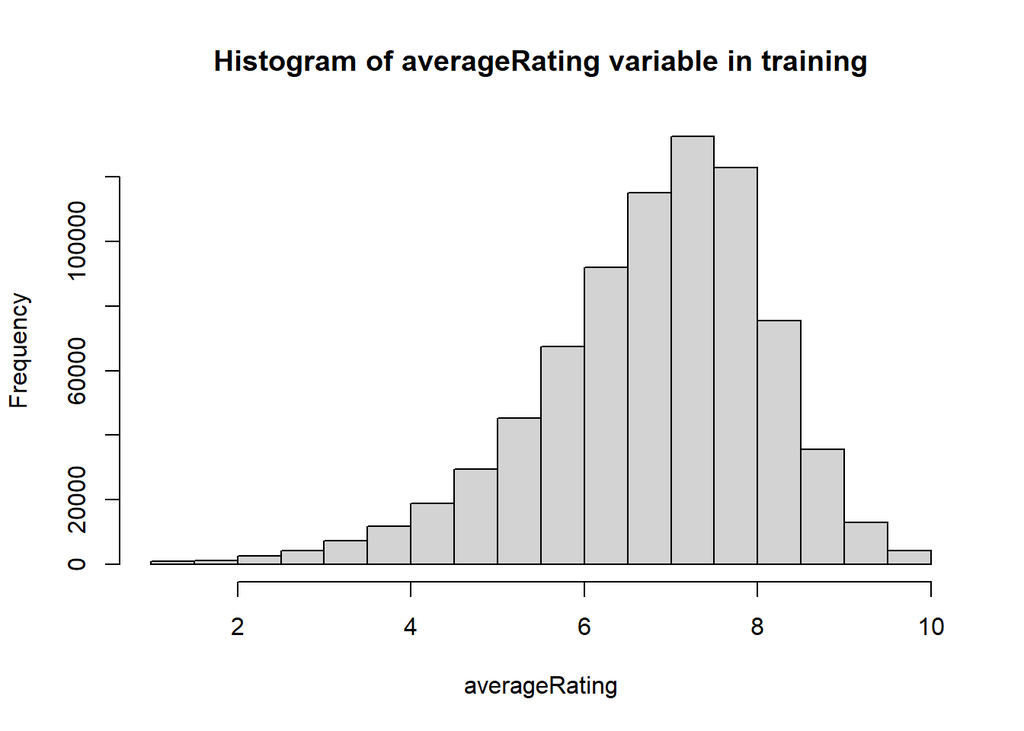

    ```r
    #histogram of Training Set averageRating
    hist(traning_data$averageRating,
         main="Histogram of averageRating variable in training",
         xlab="averageRating")
    ```

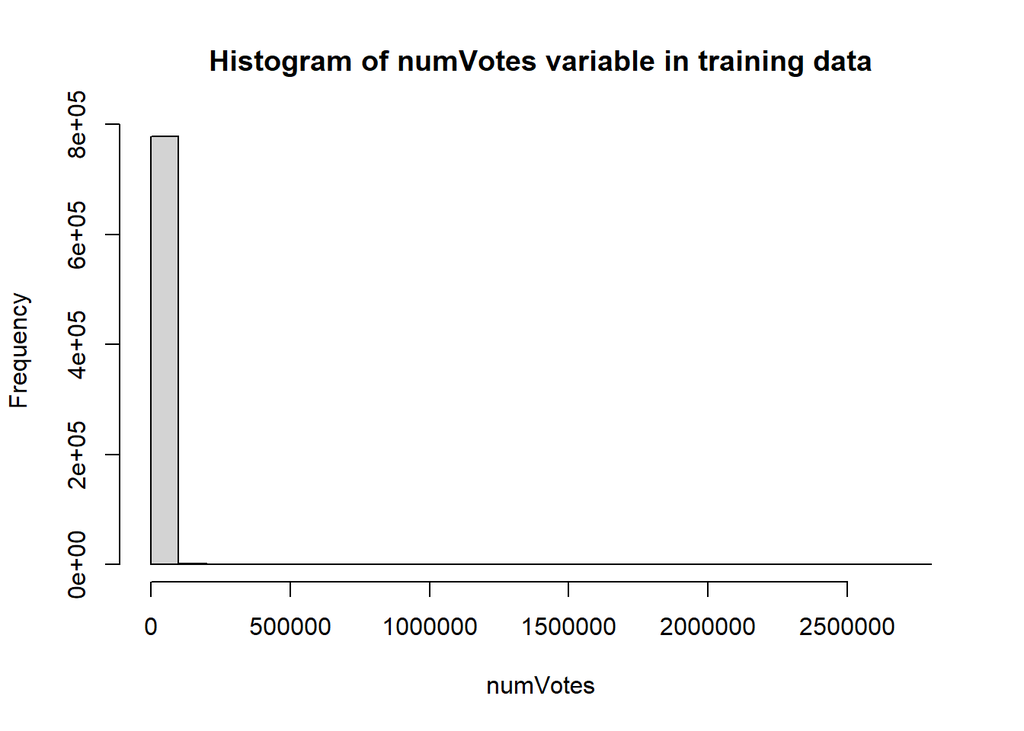

    ```r
    #histogram of Traning Set numVotes
    hist(traning_data$numVotes,
         main="Histogram of numVotes variable in training data",
         xlab="numVotes")
    ```

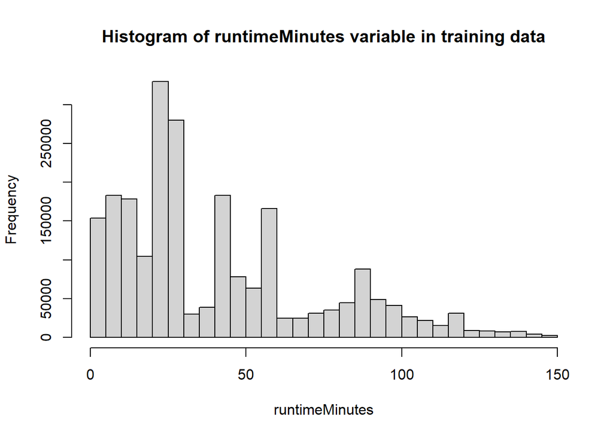

    ```r
    #histogram of traning set runtimeMinutes
    hist(traning_data$runtimeMinutes,
         main="Histogram of runtimeMinutes variable in training data",
         xlab="runtimeMinutes")
    ```

    **Histogram of Testing Data**

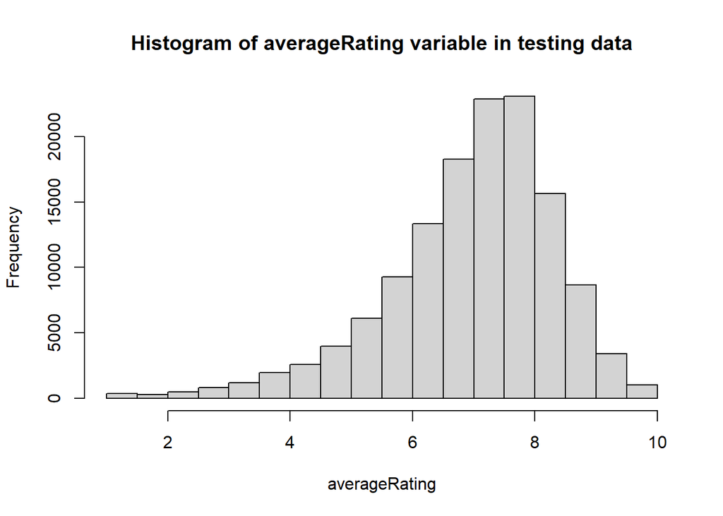

    ```r
    #Histogram of testing data averageRating
    hist(testing_data$averageRating,
         main="Histogram of averageRating variable in testing data",
         xlab="averageRating")
    ```

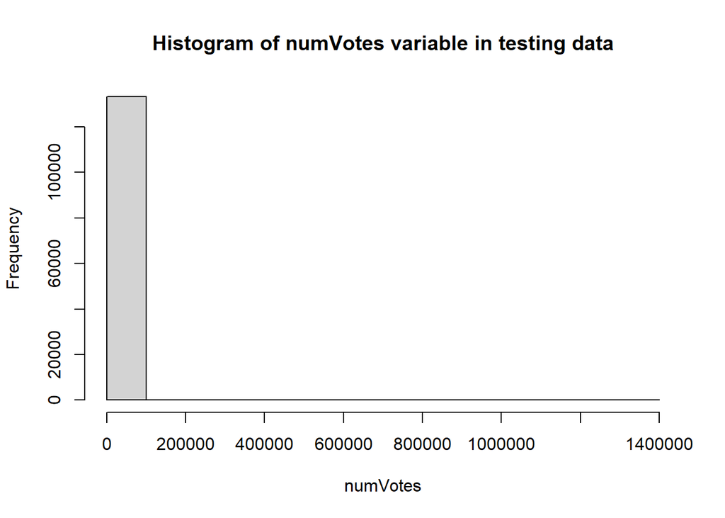

    ```r
    #Histogram of testing data numVotes
    hist(testing_data$numVotes,
         main="Histogram of numVotes variable in testing data",
         xlab="numVotes")
    ```

[figure not shown]

    ```r
    #histogram of testing data runtimeMinutes
    hist(testing_data$runtimeMinutes,
         main="Histogram of runtimeMinutes variable in training data",
         xlab="runtimeMinutes")
    ```

26. **Get boxplot of averageRating, numVotes and runtimeMinutes variables of training and testing data; compare them and interpret them carefully**

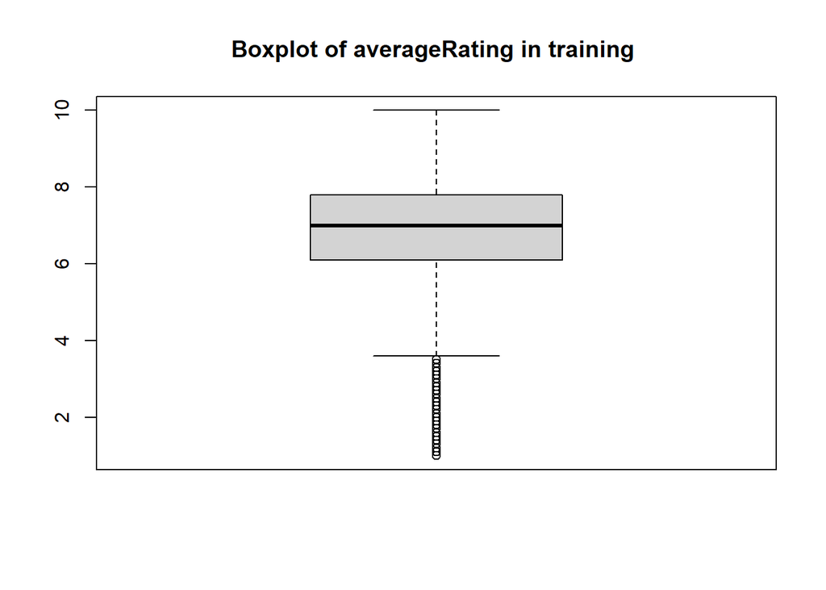

    ```r
    #boxblot of averagerating in Training Data set
    boxplot(traning_data$averageRating, main="Boxplot of averageRating in training ")
    ```

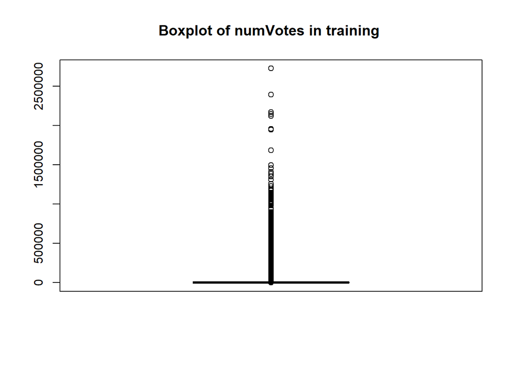

    ```r
    #boxplot of numVotes
    boxplot(traning_data$numVotes, main="Boxplot of numVotes in training ")
    ```

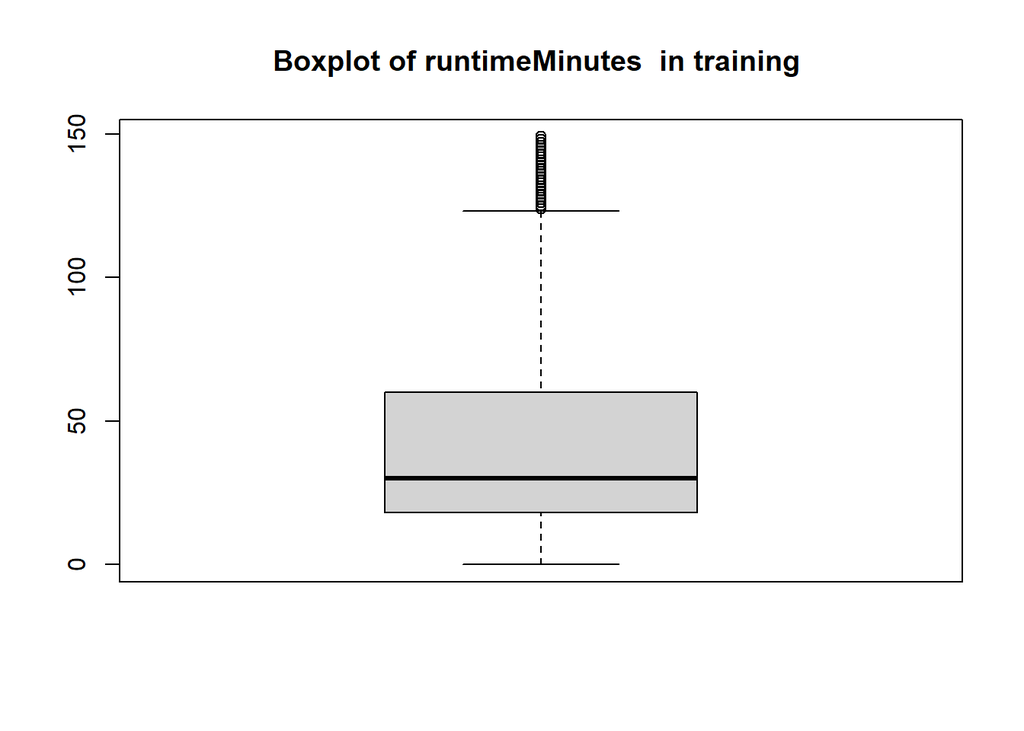

    ```r
    #boxplot of runtimeMinutes in Training data set
    boxplot(traning_data$runtimeMinutes, main="Boxplot of runtimeMinutes  in training ")
    ```

    **For Testing Data Set**

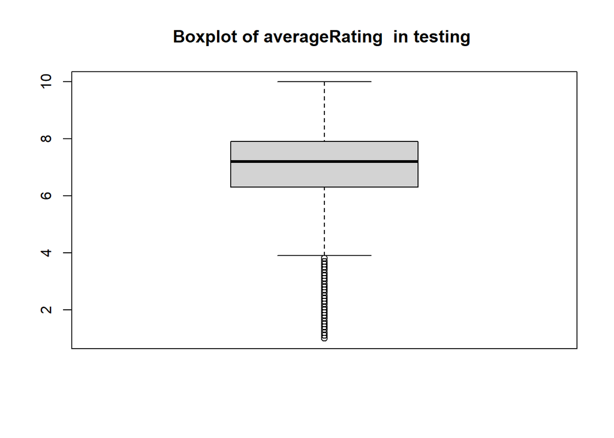

    ```r
    #boxplot of average rating in testing
    boxplot(testing_data$averageRating, main="Boxplot of averageRating  in testing ")
    ```

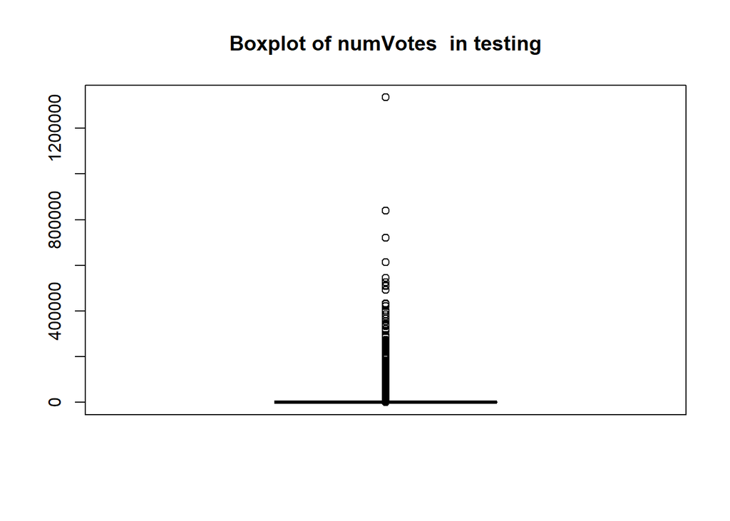

    ```r
    #boxplot of Number of Votes in Testing
    boxplot(testing_data$numVotes, main="Boxplot of numVotes  in testing")
    ```

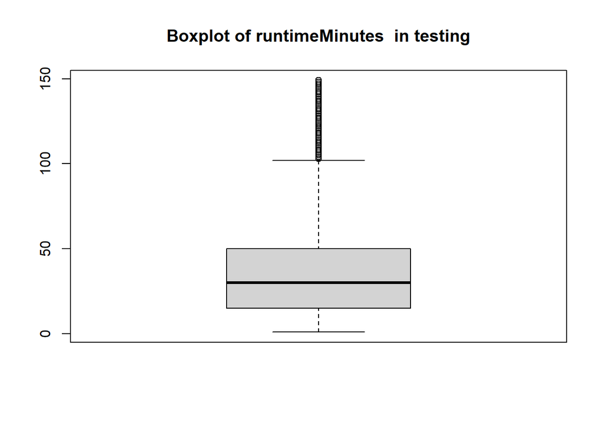

    ```r
    #boxplot of runtime Minutes in testing dataset
    boxplot(testing_data$runtimeMinutes, main="Boxplot of runtimeMinutes  in testing")
    ```